# MS Prelim Data K23

Erica Baller

2/25/2022

## MS preliminary data

Ideas:

Overall:

[] demographics - tables made below

[] imaging parameters

Aim 1: lesion network mapping [] some picture showing the # of people who are scanned and the # of people with depression. Maybe an adaptation of Syndey’s picture somehow. [] mimosa picture [] picture of filtering pipeline [] comparison of some of the histograms for high volume loss similar to prev literature(CN II, slf), not so much in other areas [] results of age analysis [maybe/maybe not, to prove the method works]? [] results of disease in vs outside of depression network (corrected), lead with this? [] results total proportion lost (single p) [] results of dep vs controls across all regions,(uncorrected) [] results of dep vs controls in depression network (uncorrected)

[] prelim network enrichment via spin-testing or just citation? - do I want to validate here or somewhere else with neurosynth maps?

Aim 2: prospective [] power analysis [] CNB (Bart has great Figure 3) [] Goassess

Aim 3 [] Hydra picture [] hydra results from my paper [] acquisition protocol (T1, t2, flair, dwi)

## R Markdown

The first chunk here is reading in appropriate data frames and preprocessing. Two big data frames are read in. The first is the demographic, drug, lab info for the MS patients (from the DAC pull). The second is the data frame of fascicle proportion affected for people with good mimosa (# volume affected/total volume of fascicle). The most important preprocessing occurs in a series of mutate commands. These essentially add new columns to the data frame that can later be used. The thrust of these mutate commands is to define who has depression and who does not.

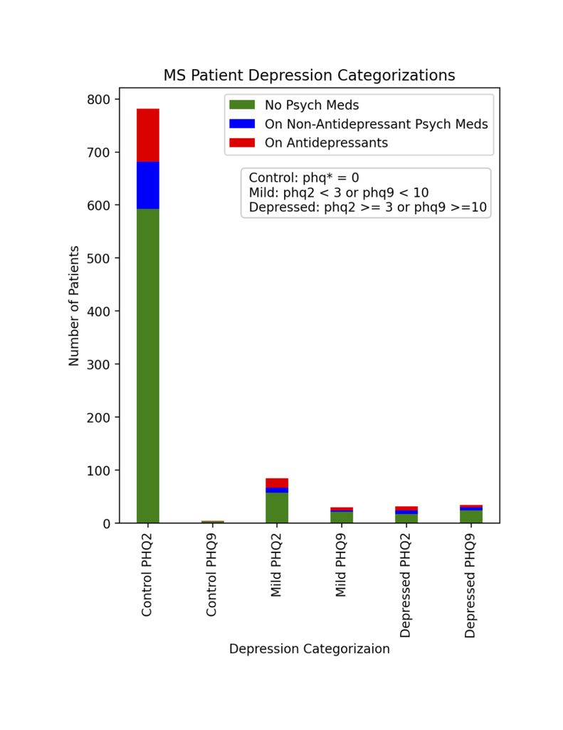

Inclusion criteria below:

Inclusion MS Criteria (dataframe read in here has already been filtered down using the exclusions below previously) 1) Scanned under MS protocol (42K) 2) MS Diagnosis (17K) 3) Seen by MS doctor (16K)

Inclusion criteria for Depressed Group 1) Have an ICD10 F3* code (in our sample, people have F32 (depressive episode), F33 (major depressive disorder), and F34 (Persistent mood [affective] disorders)) - there are NO participants with bipolar disorder, manic episode, or unspecified mood/affective disorder) - while participants may have been diagnosed with F06.3 (Depressive disorder due to known physiological condition, with depressive features), they must ALSO have had an F3(2-4) condition 2) Screened positive for depression on PHQ2 or PHQ9 at any point 3) Prescribed antidepressant medications per NAMI website - https://www.nami.org/About-Mental-Illness/Treatments/Mental-Health-Medications

Inclusion criteria for Healthy Group 1) No F* diagnoses 2) At least 1 PHQ2 or PHQ9 with a documented 0 3) Free of psychiatric medications per NAMI website

Exclusions If you received the MS protocol or had a diagnosis of MS but never actually saw an MS provider, we cannot be sure that the diagnosis of MS is truly valid, as it is hard to diagnose anyway. If you did not have a diagnosis of depression and never completed a PHQ2 or 9, and had no history of medications, we could not safely confirm nor deny the presence of depression. These subjects were excluded from future analyses. We could consider adding these to the healthy group maybe, but not too inclined to do that right now.

Imaging exclusion We are currently only using people who had good MIMOSA (75 or 100). That severely limits our numbers, but that is okay! When we re-QC, we will probably get a lot more into this group.

Final N demographics Depressed: 859 (232 unique) Super clean healthy: 604 (148 unique)

(unique, with good MIMoSA):

```
                     Healthy          Depressed             p      test
```

n 148 232  
Race (%) Caucasian 108 ( 73.0) 173 ( 74.6) 0.821  
Non-caucasian 40 ( 27.0) 59 ( 25.4)  
Sex (%) Female 117 ( 79.1) 199 ( 85.8) 0.117  
Male 31 ( 20.9) 33 ( 14.2)  
Age (mean (SD)) 46.57 (12.66) 48.75 (11.75) 0.089  
Depression (%) 1 148 (100.0) 0 ( 0.0) <0.001  
2 0 ( 0.0) 232 (100.0)  
PHQ2 (mean (SD)) 0.00 (0.00) 0.58 (1.53) <0.001  
PHQ9 (mean (SD)) 0.00 (NA) 10.43 (9.02) NA

Networks

Association fascicles: [1] “AF_L” “AF_R” “C_FPH_L” “C_FPH_R” “C_FP_L” “C_FP_R” “C_PH_L” “C_PHP_L” “C_PHP_R” “C_PH_R”  
[11] “C_R_L” “C_R_R” “EMC_L” “EMC_R” “FAT_L” “FAT_R” “IFOF_L” “IFOF_R” “ILF_L” “ILF_R”  
[21] “MdLF_L” “MdLF_R” “PAT_L” “PAT_R” “SLF1_L” “SLF1_R” “SLF2_L” “SLF2_R” “SLF3_L” “SLF3_R”  
[31] “UF_L” “UF_R” “VOF_L” “VOF_R”

Depression network: [1] “AF_L” “AF_R” “C_PHP_R” “EMC_L” “EMC_R” “FAT_L” “FAT_R” “IFOF_L” “IFOF_R” “ILF_R” “MdLF_L” [12] “MdLF_R” “PAT_L” “PAT_R” “SLF2_L” “SLF2_R” “SLF3_L” “SLF3_R” “V” “AR_R” “CBT_L” “CBT_R”  
[23] “CPT_F_L” “CPT_F_R” “CPT_O_L” “CPT_O_R” “CPT_P_L” “CPT_P_R” “CS_A_L” “CS_A_R” “CS_P_L” “CS_P_R” “CS_S_L” [34] “CS_S_R” “CST_L” “CST_R” “DRTT_R” “ML_L” “RST_L” “RST_R” “TR_A_L” “TR_A_R” “TR_P_L” “TR_P_R” [45] “TR_S_L” “TR_S_R” “CC”

Depression 10% network [1] “AF_L” “AF_R” “C_PHP_R” “FAT_L” “FAT_R” “MdLF_L” “MdLF_R” “SLF2_L” “SLF2_R” “SLF3_R” “CBT_L”  
[12] “CBT_R” “CPT_O_R” “CS_P_R” “TR_P_R”

Notebook

I start out with a proof of concept analyses, to demonstrate that our lesion filtering works. I create histograms looking at the proportion of volume lost in each fascicle across subjects. We recapitulate earlier work (will need to cite) and show that higher volume loss with our method reflects regions previously known to have higher disease burden.These findings suggest that the streamline filtering approach could be a reasonable approach for this analysis.

Analyses There are two main types of analyses I performed, t.tests (for example, to compare inside versus outside depression network) and linear models (for example, looking at the relationship of depression to each individual fascicle). With respect to T-tests, I assume unequal variance for all. For linear models, I have looked at the first scan (considered Unique for unique empi), the last scan previously (not in this notebook), and mixed models with EMPI as a repeated measure (all at the end of the notebook). I like the unique one the best. The general pattern is to look at the total proportion of volume lost across fascicles, then within depression network, within depression 10% network, and within non depression network. Then, I look at each individual fascicle, as well as separately consider the association fascicles (per DSI studio, these are the ones that connect association cortices).

I attempted to do FDR correction for all analyses where I looked at each of 87 fascicles separately, or bucketed by association network or within depression network. If i was not successful, I included uncorrected (P<0.05).

And this is only in WM. MS is also associated with GM atrophy. I can only imagine the IMCO paper that could emerge out of looking at the relationship between white matter loss and gray matter atrophy as a function of age. But certainly not for this K! Also sounds like lots of people are interested in this.

I have also looked at sex differences in individual fascicles. Underwhelming right now.

Results Depression group: 232 with depression, 148 healthy Looking at each person’s first scan:

[output not shown]

Limitations/Future directions

All diagnostic info is obtained from EMR fields, not notes, nor direct chart review. We do not know if patients are relapsing/remiting, nor do we know their active depression status. Through careful review, though patients sometimes have many phq2s listed, they are always identical.

It would be great if we also had better dimensional scores. The PHQ2s are largely 0s, and the lack of spread makes interpretation really challenging. Though the PHQ9s definitely have better spread, there just aren’t many of them. Doing really good cognitive and clinical phenotyping, or even getting a different or better set of measures into the MS clinic would be ideal (Aim 2).

With respect to networks, we have used the “depression” one from Harvard because I was inspired by the lesion network mapping work. However, the mask is pretty broad, covering and strongly overlapping with the executive network. There is bias toward having regions that functionally connect with the L DLPFC b/c it is a TMS target. We are considering neurosynth as a possible place to look at different depression masks.

Interestingly, a key topic at the ACTRIMS 2022 conference was psychiatric comorbidity. Though we are focusing on depression, it sounds like anxiety is just as bad if not worse or more highly comorbid with MS. Would be worth considering not only a DSM breakdown but dimensionally looking at internalizing disorders for the K. Also more in line with rdoc but would require changing aims a bit.

Future analyses: age x dep, sex x dep

```r
homedir <- "/Users/eballer/BBL/msdepression/"

data <- read.csv(paste0(homedir, "/data/drugs_data/parsable_msdepression.csv"), sep = ",", header = TRUE) #n=16830, only has people with MS ICD10 code G35 and seen by MS provider

columns_to_make_integer <- c("ACCESSION_NUM", "PAT_AGE_AT_EXAM","MRI_ENC_AGE","CURRENT_AGE","hemoglobin", "WBC","RBC","B12","FOLATE", "TSH", "RPR","CSFAPPEAR1","CSFAPPEAR4","CSFCOLOR1",       "CSFCOLOR4","CSFTUBE","CSFTUBE4","VitD","PHQ.2","PHQ.9")

##########################
### some preprocessing ###
##########################
#we need to keep scans from people seen by an MS provider (n = 17067) who have an MS diagnostic code (n=16,830)
#we make a bunch of columns from character to integer, binarize sex and race, and put date into a nice format YYYYMMDD, the %m%d%y indicates what it started out as

#goal is to keep people who were seen by
 data_empi_acc_f_phq <- data %>%
   mutate(across(.cols = columns_to_make_integer, .fns = as.integer)) %>%
   mutate(sex_binarized = ifelse(SEX == "MALE", 1, 2)) %>%
   mutate(osex = ordered(sex_binarized,levels = c(1,2), labels = c("Male","Female"))) %>%
   mutate(race_binarized = ifelse(RACE == "WHITE", 1, 2)) %>%
   mutate(orace = ordered(race_binarized,levels = c(1,2), labels = c("White","Non-white"))) %>%
   mutate(EXAM_DATE = as.Date(BEGIN_EXAM_DTTM, format = "%m/%d/%y")) %>%
   mutate(EXAM_DATE = gsub(EXAM_DATE, pattern = "-", replacement = "")) %>%
   mutate(EMPI = as.factor(EMPI)) %>%
   mutate(On.Psych.Meds = ifelse(On.Psych.Meds == "True", 1, 0)) %>%
   mutate(On.Antidepressants = ifelse(On.Antidepressants == "True", 1, 0)) %>%
   mutate(Has.PHQ2 = ifelse(Has.PHQ2 == "True", 1, 0)) %>%
   mutate(Has.PHQ9 = ifelse(Has.PHQ9 == "True", 1, 0)) %>%
   mutate(Has.depdx = ifelse(grepl("F3", ICD10), 1, 0)) %>%
   mutate(PHQ.2_modsev_dep_sxs = ifelse((!is.na(PHQ.2) & PHQ.2 >= 3), 1, 0)) %>%
   mutate(PHQ.9_modsev_dep_sxs = ifelse((!is.na(PHQ.9) & PHQ.9 >= 10), 1, 0)) %>%
   mutate(PHQ.2_mild_dep_sxs = ifelse((!is.na(PHQ.2) & PHQ.2 > 0 & PHQ.2 < 3), 1, 0)) %>%
   mutate(PHQ.9_mild_dep_sxs = ifelse((!is.na(PHQ.9) & PHQ.9 > 0 & PHQ.9 < 10), 1, 0)) %>%
   mutate(PHQ.2_zero = ifelse((!is.na(PHQ.2) & PHQ.2 == 0), 1, 0)) %>%
   mutate(PHQ.9_zero = ifelse((!is.na(PHQ.9) & PHQ.9 == 0), 1, 0)) %>%
   mutate(dep_by_dx_phq = ifelse((Has.depdx | PHQ.2_modsev_dep_sxs | PHQ.9_modsev_dep_sxs),1,0)) %>%
   mutate(dep_by_dx_phq_antidep = ifelse((Has.depdx | On.Antidepressants | PHQ.2_modsev_dep_sxs | PHQ.9_modsev_dep_sxs),1,0)) %>%
   mutate(true_healthy = ifelse((!Has.depdx & !On.Psych.Meds & (PHQ.2_zero | PHQ.9_zero)), 1, 0)) %>%
   mutate(dep_by_dx_phq_meds_healthy_phq0_no_psych_meds = ifelse(dep_by_dx_phq_antidep | true_healthy, 1, 0)) %>%
   rowwise(ACCESSION_NUM) %>%
   mutate(depGroupVar =
            sum(c(dep_by_dx_phq_meds_healthy_phq0_no_psych_meds,dep_by_dx_phq_antidep))) %>%#you get an extra point if you are in the depression group, so the end result is dep = 2, healthy = 1, 0 for exclude
   ungroup()
```

```
## Note: Using an external vector in selections is ambiguous.
## ℹ Use `all_of(columns_to_make_integer)` instead of `columns_to_make_integer` to silence this message.
## ℹ See <https://tidyselect.r-lib.org/reference/faq-external-vector.html>.
```

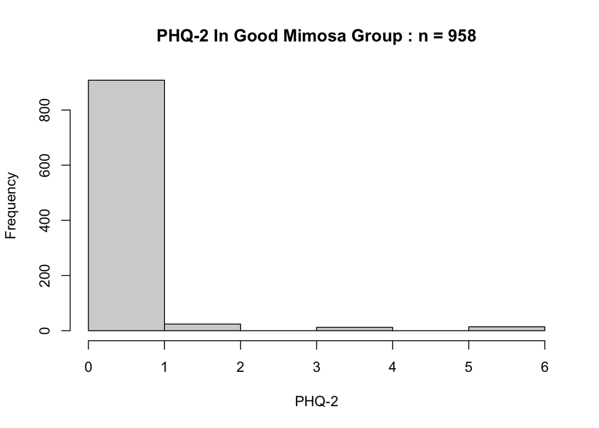

```r
##########################################################
#             Read in Fascicle info             #
##########################################################

fascicle_proportions <- read.csv(paste0(homedir, "/results/fascicle_volumes_all_subjects_roi_n2336.csv"), header = T, sep = ",") #n = 2336

#fascicle names are contained in all but the first 2 columns of the fascicle_proportions df
fascicle_names <- names(fascicle_proportions[3:dim(fascicle_proportions)[2]])

write.table(fascicle_names,"/Users/eballer/BBL/msdepression/templates/dti/HCP_YA1065_tractography/fascicle_names.csv", row.names = F, quote = F, col.names = F)


########
#fascicle volumes in depression network
########
fascicle_volumes_dep <- read.csv(paste0(homedir, "results/streamline_volume_within_dep_network.csv"), header = T, sep = ",")

#add column to indicate whether does not meet criteria for inclusion in dep mask (0), any overlapping voxels (1), or >10% overlapping voxels (2)
fascicle_volumes_dep_network <- fascicle_volumes_dep %>%
  replace(is.na(.), 0) %>%
  mutate(inDepMask=case_when(prop_in_mask == 0 ~ 0, (prop_in_mask > 0 & prop_in_mask < 0.1) ~ 1, prop_in_mask >= 0.1 ~ 2))



write.table(fascicle_volumes_dep_network, paste0(homedir,  "/templates/dti/HCP_YA1065_tractography/fascicle_names_dep_network_grouping.csv"), sep = ",", col.names=T)#, row.names = F, quote = F, col.names = T)

fascicle_names_nondep_network<- fascicle_volumes_dep_network$fascicle[which(fascicle_volumes_dep_network$inDepMask == 0)]

fascicle_names_dep_network_all <- fascicle_volumes_dep_network$fascicle[which(fascicle_volumes_dep_network$inDepMask > 0)]

#fascicle_names_dep_network_all <- fascicle_volumes_dep_network$fascicle[which(fascicle_volumes_dep_network$inDepMask == 1)]
#write.table(fascicle_names_dep_network_all,"/Users/eballer/BBL/msdepression/templates/dti/HCP_YA1065_tractography/fascicle_names_dep_network_all.csv", row.names = F, quote = F, col.names = F)


fascicle_names_dep_network_10_percent <- fascicle_volumes_dep_network$fascicle[which(fascicle_volumes_dep_network$inDepMask == 2)] #n=15
#write.table(fascicle_names_dep_network_10_percent,"/Users/eballer/BBL/msdepression/templates/dti/HCP_YA1065_tractography/fascicle_names_dep_network_10_percent.csv", row.names = F, quote = F, col.names = F)

fascicle_names_dep_network_5_percent <- fascicle_volumes_dep_network$fascicle[which(fascicle_volumes_dep_network$prop_in_mask >= 0.05)] #n=24

#fascicle_mapping, returns numerical mapping as well as names of tracts, and whether in or out of dep network
fascicle_bundle_mapping <- get_fascicle_bundle_mapping()

##########################################################
#             Merge with data_empi              #
##########################################################
df_demo_and_fascicles <- merge(data_empi_acc_f_phq, fascicle_proportions, by = c("EMPI", "EXAM_DATE")) #n = 2962
##########################################################
#                 Histos                        #
##########################################################
##### Histograms for PHQ2/9 healthy and depressed

hist(df_demo_and_fascicles$PHQ.2[which(!is.na(df_demo_and_fascicles$PHQ.2))], main = paste0("PHQ-2 In Good Mimosa Group : n = ", length(which(!is.na(df_demo_and_fascicles$PHQ.2)))), xlab = "PHQ-2", breaks = 8)
```

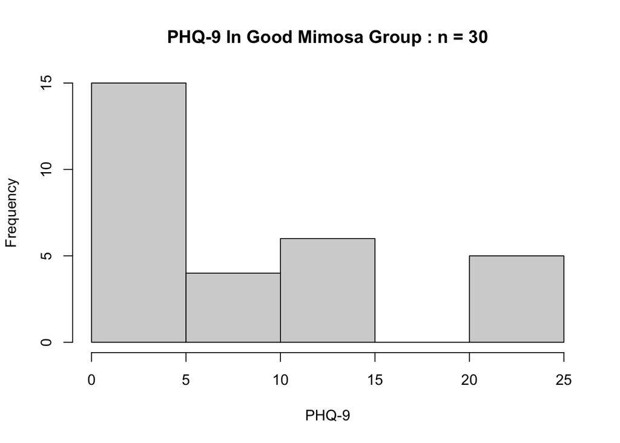

```r
hist(df_demo_and_fascicles$PHQ.9[which(!is.na(df_demo_and_fascicles$PHQ.9))], main = paste0("PHQ-9 In Good Mimosa Group : n = ", length(which(!is.na(df_demo_and_fascicles$PHQ.9)))), xlab = "PHQ-9", breaks = 8)
```

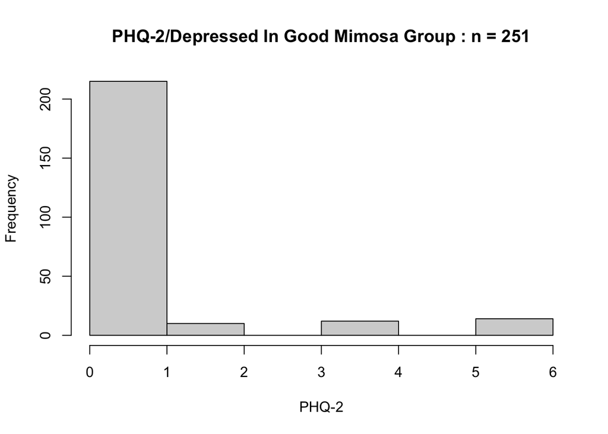

```r
phq2_and_dep <- df_demo_and_fascicles %>% filter(depGroupVar == 2) %>% drop_na(PHQ.2)
phq9_and_dep <- df_demo_and_fascicles %>% filter(depGroupVar == 2) %>% drop_na(PHQ.9)
phq2_and_healthy <- df_demo_and_fascicles %>% filter(Has.depdx == 0) %>% drop_na(PHQ.2)
phq9_and_healthy <- df_demo_and_fascicles %>% filter(Has.depdx == 0) %>% drop_na(PHQ.9)

hist(phq2_and_dep$PHQ.2, main = paste0("PHQ-2/Depressed In Good Mimosa Group : n = ", dim(phq2_and_dep)[1]), xlab = "PHQ-2", breaks = 8)
```

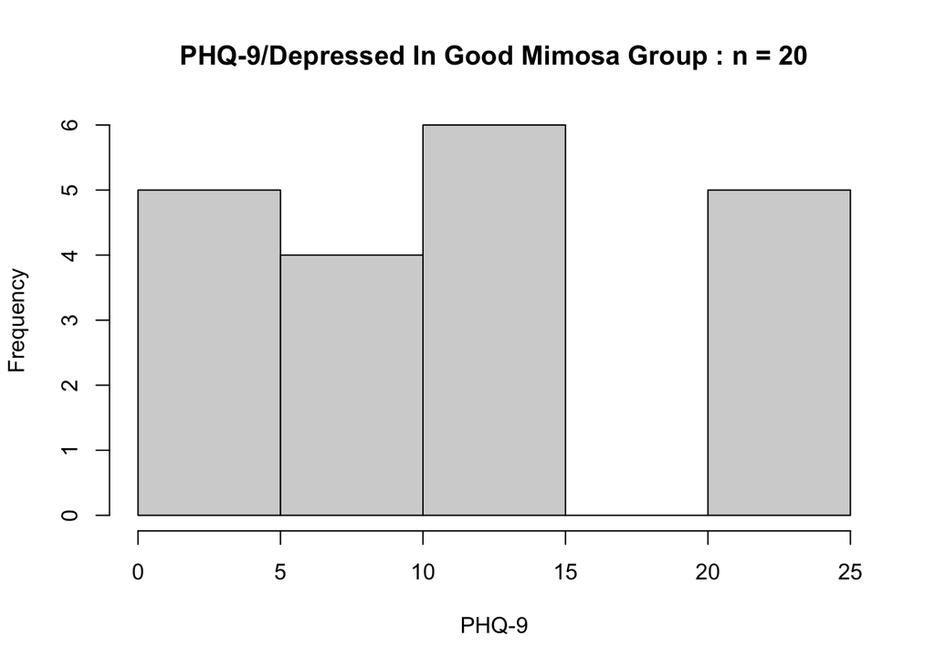

```r
hist(phq9_and_dep$PHQ.9, main = paste0("PHQ-9/Depressed In Good Mimosa Group : n = ", dim(phq9_and_dep)[1]), xlab = "PHQ-9", breaks = 8)
```

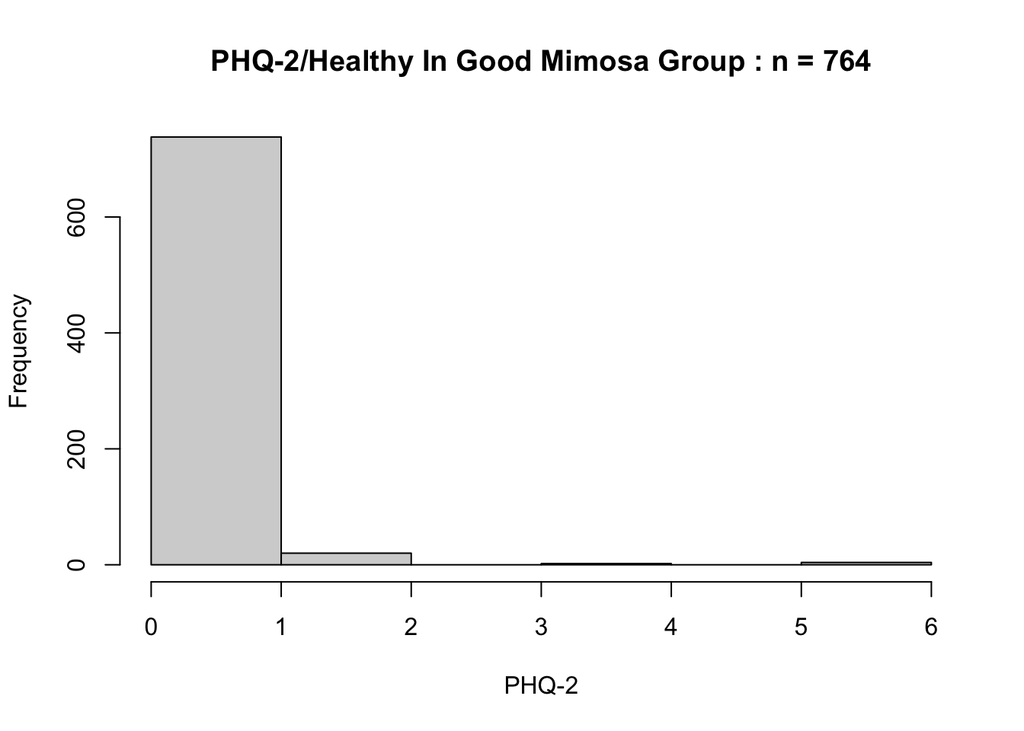

```r
hist(phq2_and_healthy$PHQ.2, main = paste0("PHQ-2/Healthy In Good Mimosa Group : n = ", dim(phq2_and_healthy)[1]), xlab = "PHQ-2", breaks = 8)
```

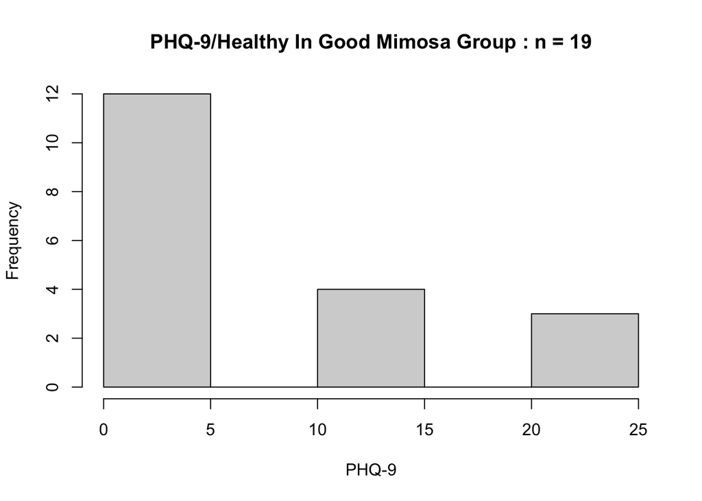

```r
hist(phq9_and_healthy$PHQ.9, main = paste0("PHQ-9/Healthy In Good Mimosa Group : n = ", dim(phq9_and_healthy)[1]), xlab = "PHQ-9", breaks = 8)
```

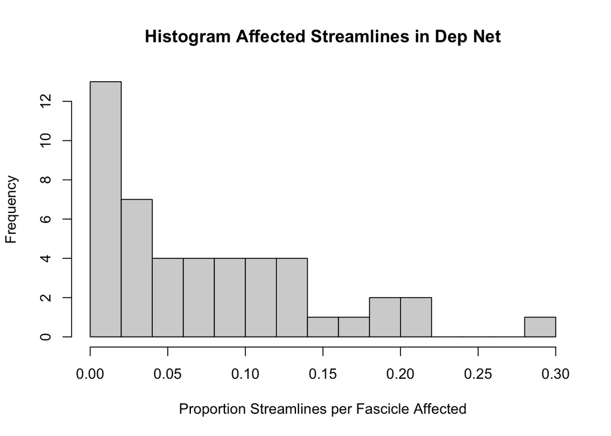

```r
######## Histograms for depression network
#this histogram helps contextualize the number of streamlines with varying degrees of proportions affected
hist(x=fascicle_volumes_dep$prop_in_mask, main = "Histogram Affected Streamlines in Dep Net", xlab = "Proportion Streamlines per Fascicle Affected", breaks = 20)
```

## Depression versus healthy analysis

```r
#this will display a demographics table comparing age, race, sex between healthy and depressed groups, using the first presentation to treatment

make_demographics_table_ms(data_frame = data_empi_acc_f_phq)
```

```
##                   Stratified by Depression
##                    level         0              1              2
##   n                               9452           2608           4770
##   Race (%)         Caucasian      6885 ( 72.8)   1836 ( 70.4)   3453 ( 72.4)
##                    Non-caucasian  2567 ( 27.2)    772 ( 29.6)   1317 ( 27.6)
##   Sex (%)          Female         6860 ( 72.6)   2005 ( 76.9)   3878 ( 81.3)
##                    Male           2592 ( 27.4)    603 ( 23.1)    892 ( 18.7)
##   Age (mean (SD))                46.74 (12.16)  45.95 (12.66)  48.47 (12.12)
##   Depression (%)   0              9452 (100.0)      0 (  0.0)      0 (  0.0)
##                    1                 0 (  0.0)   2608 (100.0)      0 (  0.0)
##                    2                 0 (  0.0)      0 (  0.0)   4770 (100.0)
##   PHQ2 (mean (SD))                0.50 (0.75)    0.00 (0.00)    0.61 (1.44)
##   PHQ9 (mean (SD))                5.11 (2.60)    0.00 (0.00)   10.99 (6.77)
##                   Stratified by Depression
##                    p      test
##   n
##   Race (%)          0.047
##
##   Sex (%)          <0.001
##
##   Age (mean (SD))  <0.001
##   Depression (%)   <0.001
##
##
##   PHQ2 (mean (SD)) <0.001
##   PHQ9 (mean (SD)) <0.001
```

```r
df_unique_empi <- data_empi_acc_f_phq %>%
  group_by(EMPI) %>%
  arrange(EXAM_DATE) %>%
  slice(1) %>%
  ungroup()

make_demographics_table_ms(data_frame = df_unique_empi)
```

```
##                   Stratified by Depression
##                    level         0              1              2
##   n                               2183            488           1066
##   Race (%)         Caucasian      1503 ( 68.9)    312 ( 63.9)    750 ( 70.4)
##                    Non-caucasian   680 ( 31.1)    176 ( 36.1)    316 ( 29.6)
##   Sex (%)          Female         1596 ( 73.1)    371 ( 76.0)    864 ( 81.1)
##                    Male            587 ( 26.9)    117 ( 24.0)    202 ( 18.9)
##   Age (mean (SD))                45.14 (12.37)  44.33 (12.78)  47.43 (12.28)
##   Depression (%)   0              2183 (100.0)      0 (  0.0)      0 (  0.0)
##                    1                 0 (  0.0)    488 (100.0)      0 (  0.0)
##                    2                 0 (  0.0)      0 (  0.0)   1066 (100.0)
##   PHQ2 (mean (SD))                0.54 (0.76)    0.00 (0.00)    0.73 (1.55)
##   PHQ9 (mean (SD))                5.45 (2.70)    0.00 (0.00)   11.37 (6.84)
##                   Stratified by Depression
##                    p      test
##   n
##   Race (%)          0.038
##
##   Sex (%)          <0.001
##
##   Age (mean (SD))  <0.001
##   Depression (%)   <0.001
##
##
##   PHQ2 (mean (SD)) <0.001
##   PHQ9 (mean (SD))  0.001
```

```r
df_just_healthy_and_depressed <- df_unique_empi %>% filter(depGroupVar != 0)

make_demographics_table_ms(data_frame = df_just_healthy_and_depressed)
```

```
##                   Stratified by Depression
##                    level         1              2              p      test
##   n                                488           1066
##   Race (%)         Caucasian       312 ( 63.9)    750 ( 70.4)   0.014
##                    Non-caucasian   176 ( 36.1)    316 ( 29.6)
##   Sex (%)          Female          371 ( 76.0)    864 ( 81.1)   0.027
##                    Male            117 ( 24.0)    202 ( 18.9)
##   Age (mean (SD))                44.33 (12.78)  47.43 (12.28)  <0.001
##   Depression (%)   1               488 (100.0)      0 (  0.0)  <0.001
##                    2                 0 (  0.0)   1066 (100.0)
##   PHQ2 (mean (SD))                0.00 (0.00)    0.73 (1.55)   <0.001
##   PHQ9 (mean (SD))                0.00 (0.00)   11.37 (6.84)    0.006
```

```r
#just people with good mimosa
df_good_mimosa <- df_demo_and_fascicles %>% filter(depGroupVar != 0)
make_demographics_table_ms(data_frame = df_good_mimosa)
```

```
##                   Stratified by Depression
##                    level         1              2              p      test
##   n                                604            859
##   Race (%)         Caucasian       459 ( 76.0)    658 ( 76.6)   0.836
##                    Non-caucasian   145 ( 24.0)    201 ( 23.4)
##   Sex (%)          Female          484 ( 80.1)    719 ( 83.7)   0.091
##                    Male            120 ( 19.9)    140 ( 16.3)
##   Age (mean (SD))                46.17 (12.23)  48.39 (11.94)   0.001
##   Depression (%)   1               604 (100.0)      0 (  0.0)  <0.001
##                    2                 0 (  0.0)    859 (100.0)
##   PHQ2 (mean (SD))                0.00 (0.00)    0.64 (1.60)   <0.001
##   PHQ9 (mean (SD))                0.00 (0.00)   10.20 (8.15)    0.099
```

```r
df_good_mimosa_unique <- df_demo_and_fascicles %>%
  filter(depGroupVar != 0) %>%
  group_by(EMPI) %>%
  arrange(EXAM_DATE) %>%
  slice(1) %>%
  ungroup()
make_demographics_table_ms(data_frame = df_good_mimosa_unique)
```

```
##                   Stratified by Depression
##                    level         1              2              p      test
##   n                                148            232
##   Race (%)         Caucasian       108 ( 73.0)    173 ( 74.6)   0.821
##                    Non-caucasian    40 ( 27.0)     59 ( 25.4)
##   Sex (%)          Female          117 ( 79.1)    199 ( 85.8)   0.117
##                    Male             31 ( 20.9)     33 ( 14.2)
##   Age (mean (SD))                46.57 (12.66)  48.75 (11.75)   0.089
##   Depression (%)   1               148 (100.0)      0 (  0.0)  <0.001
##                    2                 0 (  0.0)    232 (100.0)
##   PHQ2 (mean (SD))                0.00 (0.00)    0.58 (1.53)   <0.001
##   PHQ9 (mean (SD))                0.00 (NA)     10.43 (9.02)       NA
```

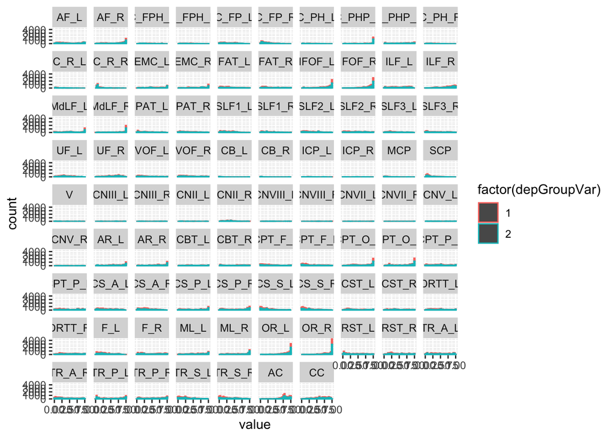

```r
#this section creates histograms looking at the proportion of volume lost in each fascicle across subjects
#we recapitulate earlier work and show that higher volume loss with our method reflects regions previously known to have higher volume loss
#These findings suggest that the streamline filtering approach could be a reasonable approach for this analysis

#have to pull out just the pieces I'm interested in
just_dep_and_empi <- subset(data_empi_acc_f_phq, select = c("EMPI", "depGroupVar"))
added_dep_to_fascicles <- merge(just_dep_and_empi, fascicle_proportions, by = c("EMPI"))
melted_df <- melt(added_dep_to_fascicles, id.vars = c("EMPI", "EXAM_DATE", "depGroupVar"))

#exclude regions where there was no lesion at all
lesioned <- subset(melted_df, value > 0)

#only include people in healthy or depressed group
lesioned_dx <- subset(lesioned, depGroupVar != 0)

#separate out healthy and depressed
healthy <- subset(lesioned, depGroupVar == 1)
depressed <- subset(lesioned, depGroupVar == 2)

q<-ggplot(lesioned, aes(x=value, fill=depGroupVar)) + geom_histogram() + facet_wrap(~variable)
r<-ggplot(lesioned_dx, aes(x=value, fill=depGroupVar)) + geom_histogram() + facet_wrap(~variable)
r_color<-ggplot(lesioned_dx, aes(x=value, color=factor(depGroupVar))) + geom_histogram() + facet_wrap(~variable)
x<-ggplot(lesioned, aes(x=value)) + geom_histogram() + facet_wrap(~variable)
y<-ggplot(healthy, aes(x=value)) + geom_histogram() + facet_wrap(~variable)
z<-ggplot(depressed, aes(x=value)) + geom_histogram() + facet_wrap(~variable)

#print(q)
#print(r)
print(r_color)
```

```r
#print(x)
#print(y)
#print(z)
```

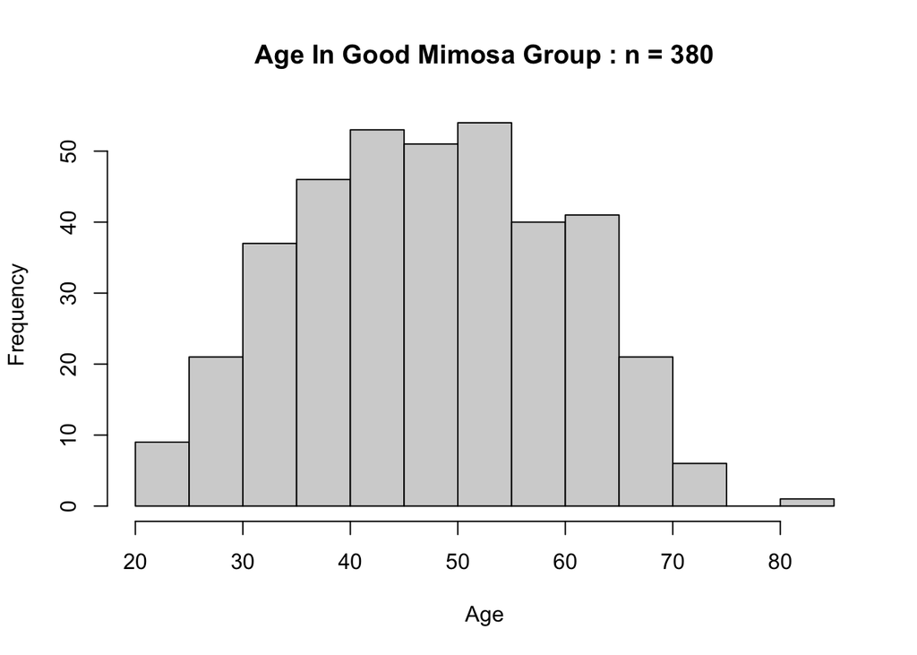

```r
########### age effect whole group

#isolate out only the depressed group and healthy group
dep_and_healthy_groups_for_ICD_analysis <- df_demo_and_fascicles %>%
  filter(depGroupVar != 0)  %>%
  group_by(EMPI) %>%
  arrange(EXAM_DATE) %>%
  slice(1) %>%
  ungroup()


#### age histo ###
hist(dep_and_healthy_groups_for_ICD_analysis$PAT_AGE_AT_EXAM,
main = paste0("Age In Good Mimosa Group : n = ", dim(dep_and_healthy_groups_for_ICD_analysis)[1]), xlab = "Age", breaks = 10)
```

```r
#lm
fascicle_age_lm <- lapply(fascicle_names, function(x)
{
  lm(substitute(i ~ PAT_AGE_AT_EXAM, list(i = as.name(x))), data = dep_and_healthy_groups_for_ICD_analysis)
})
names(fascicle_age_lm) <- fascicle_names

#anova
fascicle_age_anova <- lapply(fascicle_age_lm, anova)

#fdr corrected
fascicle_age_anova_fdr <- fdr_anova_generic(fascicle_age_anova, 1)
```

```
##               p_anova
## AF_L     1.310089e-04
## AF_R     6.949010e-03
## C_FPH_L  4.425597e-02
## C_FPH_R  9.013201e-01
## C_FP_L   1.057222e-02
## C_FP_R   1.756199e-01
## C_PH_L   6.944955e-01
## C_PHP_L  1.395585e-02
## C_PHP_R  4.952570e-03
## C_PH_R   2.931716e-02
## C_R_L    3.895358e-01
## C_R_R    6.220627e-01
## EMC_L    2.741087e-03
## EMC_R    5.201642e-03
## FAT_L    1.332697e-06
## FAT_R    5.112076e-08
## IFOF_L   1.173274e-05
## IFOF_R   5.828317e-04
## ILF_L    9.092300e-04
## ILF_R    3.065550e-02
## MdLF_L   4.787630e-03
## MdLF_R   1.678200e-01
## PAT_L    4.237933e-03
## PAT_R    2.143517e-03
## SLF1_L   3.090508e-03
## SLF1_R   1.115472e-01
## SLF2_L   3.981497e-04
## SLF2_R   3.517620e-05
## SLF3_L   5.209602e-06
## SLF3_R   1.705280e-08
## UF_L     2.819459e-06
## UF_R     1.393987e-09
## VOF_L    9.045875e-02
## VOF_R    2.545034e-03
## CB_L     1.736690e-01
## CB_R     5.141270e-01
## ICP_L    7.339899e-01
## ICP_R    1.499169e-01
## MCP      8.930558e-01
```

[output cut: 33 more lines]

```
## F_R      4.089012e-01
## ML_L     4.506021e-01
## ML_R     3.580214e-01
## OR_L     5.058345e-04
## OR_R     1.654767e-03
## RST_L    4.603385e-08
## RST_R    5.637520e-07
## TR_A_L   1.838190e-12
## TR_A_R   1.900999e-08
## TR_P_L   1.989410e-02
## TR_P_R   3.232031e-02
## TR_S_L   3.157539e-05
## TR_S_R   4.215605e-04
## AC       2.808699e-03
## CC       1.264964e-04
```

```r
print(fascicle_age_anova_fdr)
```

```
##    component p_FDR_corr
## 1       AF_L          0
## 2       AF_R      0.014
## 3     C_FP_L       0.02
## 4    C_PHP_L      0.025
## 5    C_PHP_R      0.011
## 6     C_PH_R      0.048
## 7      EMC_L      0.007
## 8      EMC_R      0.011
## 9      FAT_L          0
## 10     FAT_R          0
## 11    IFOF_L          0
## 12    IFOF_R      0.002
## 13     ILF_L      0.003
## 14     ILF_R      0.049
```

[output cut: 40 more lines]

```r
#fdr corrected only association cortex
fascicle_anova_w_fiber_mapping <- fascicle_age_anova[which(fascicle_bundle_mapping$name_vector == "association")]
fascicle_anova_fdr_association <- fdr_anova_generic(fascicle_anova_w_fiber_mapping,1)
```

```
##              p_anova
## AF_L    1.310089e-04
## AF_R    6.949010e-03
## C_FPH_L 4.425597e-02
## C_FPH_R 9.013201e-01
## C_FP_L  1.057222e-02
## C_FP_R  1.756199e-01
## C_PH_L  6.944955e-01
## C_PHP_L 1.395585e-02
## C_PHP_R 4.952570e-03
## C_PH_R  2.931716e-02
## C_R_L   3.895358e-01
## C_R_R   6.220627e-01
## EMC_L   2.741087e-03
## EMC_R   5.201642e-03
## FAT_L   1.332697e-06
## FAT_R   5.112076e-08
## IFOF_L  1.173274e-05
## IFOF_R  5.828317e-04
## ILF_L   9.092300e-04
## ILF_R   3.065550e-02
## MdLF_L  4.787630e-03
## MdLF_R  1.678200e-01
## PAT_L   4.237933e-03
## PAT_R   2.143517e-03
## SLF1_L  3.090508e-03
## SLF1_R  1.115472e-01
## SLF2_L  3.981497e-04
## SLF2_R  3.517620e-05
## SLF3_L  5.209602e-06
## SLF3_R  1.705280e-08
## UF_L    2.819459e-06
## UF_R    1.393987e-09
## VOF_L   9.045875e-02
## VOF_R   2.545034e-03
```

```r
print(fascicle_anova_fdr_association)
```

```
##    component p_FDR_corr
## 1       AF_L          0
## 2       AF_R      0.011
## 3     C_FP_L      0.016
## 4    C_PHP_L      0.021
## 5    C_PHP_R      0.009
## 6     C_PH_R      0.042
## 7      EMC_L      0.006
## 8      EMC_R      0.009
## 9      FAT_L          0
## 10     FAT_R          0
## 11    IFOF_L          0
## 12    IFOF_R      0.002
## 13     ILF_L      0.003
## 14     ILF_R      0.042
## 15    MdLF_L      0.009
## 16     PAT_L      0.008
## 17     PAT_R      0.006
## 18    SLF1_L      0.007
## 19    SLF2_L      0.001
## 20    SLF2_R          0
## 21    SLF3_L          0
## 22    SLF3_R          0
## 23      UF_L          0
## 24      UF_R          0
## 25     VOF_R      0.006
```

```r
#visreg
#sapply(fascicle_age_lm,visreg)
```

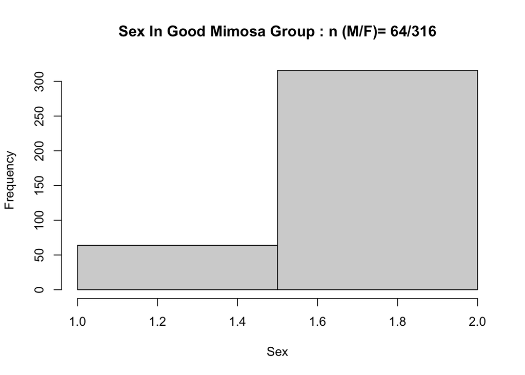

```r
### really not interesting at all. 3 areas that are uncorrected: SCP, CPT_O_R, OR_R

#isolate out only the depressed group and healthy group
dep_and_healthy_groups_for_ICD_analysis <- df_demo_and_fascicles %>% filter(depGroupVar != 0)  %>%
  group_by(EMPI) %>%
  arrange(EXAM_DATE) %>%
  slice(1) %>%
  ungroup()

#### sex histo ###
hist(dep_and_healthy_groups_for_ICD_analysis$sex_binarized,
main = paste0("Sex In Good Mimosa Group : n (M/F)= ", sum(dep_and_healthy_groups_for_ICD_analysis$sex_binarized == 1), "/", sum(dep_and_healthy_groups_for_ICD_analysis$sex_binarized == 2)),  xlab = "Sex", breaks = 2)
```

```r
#lm
fascicle_sex_lm <- lapply(fascicle_names, function(x)
{
  lm(substitute(i ~ osex, list(i = as.name(x))), data = dep_and_healthy_groups_for_ICD_analysis)
})
names(fascicle_sex_lm) <- fascicle_names

#anova
fascicle_sex_anova <- lapply(fascicle_sex_lm, anova)

#fdr corrected
fascicle_sex_anova_fdr <- fdr_anova_generic(fascicle_sex_anova, 1)
```

```
##             p_anova
## AF_L     0.44739266
## AF_R     0.64416738
## C_FPH_L  0.94437159
## C_FPH_R  0.53001016
## C_FP_L   0.48158913
## C_FP_R   0.80476904
## C_PH_L   0.61020308
## C_PHP_L  0.67545646
## C_PHP_R  0.07801124
## C_PH_R   0.10468261
## C_R_L    0.69227951
## C_R_R    0.98937394
## EMC_L    0.65989277
## EMC_R    0.82951422
## FAT_L    0.50035207
## FAT_R    0.77136690
## IFOF_L   0.92843465
## IFOF_R   0.23656430
## ILF_L    0.91105639
## ILF_R    0.30099126
## MdLF_L   0.77788757
## MdLF_R   0.78066200
## PAT_L    0.86985177
## PAT_R    0.57869897
## SLF1_L   0.65107626
## SLF1_R   0.42036259
## SLF2_L   0.36090055
## SLF2_R   0.97316633
## SLF3_L   0.38815774
## SLF3_R   0.50987210
## UF_L     0.95985961
## UF_R     0.93716889
## VOF_L    0.38583828
## VOF_R    0.95224203
## CB_L     0.63783304
## CB_R     0.76441140
## ICP_L    0.77509495
## ICP_R    0.18945834
## MCP      0.32136336
```

[output cut: 33 more lines]

```
## F_R      0.67638975
## ML_L     0.37068476
## ML_R     0.35207309
## OR_L     0.34692466
## OR_R     0.03134048
## RST_L    0.58358562
## RST_R    0.82993497
## TR_A_L   0.87865704
## TR_A_R   0.79047829
## TR_P_L   0.50045358
## TR_P_R   0.53155061
## TR_S_L   0.58894961
## TR_S_R   0.62770144
## AC       0.22363790
## CC       0.32643168
```

```r
print(fascicle_sex_anova_fdr)
```

```
## [1] component  p_FDR_corr
## <0 rows> (or 0-length row.names)
```

```r
#fdr corrected only association cortex
fascicle_anova_w_fiber_mapping <- fascicle_sex_anova[which(fascicle_bundle_mapping$name_vector == "association")]
fascicle_anova_fdr_association <- fdr_anova_generic(fascicle_anova_w_fiber_mapping,1)
```

```
##            p_anova
## AF_L    0.44739266
## AF_R    0.64416738
## C_FPH_L 0.94437159
## C_FPH_R 0.53001016
## C_FP_L  0.48158913
## C_FP_R  0.80476904
## C_PH_L  0.61020308
## C_PHP_L 0.67545646
## C_PHP_R 0.07801124
## C_PH_R  0.10468261
## C_R_L   0.69227951
## C_R_R   0.98937394
## EMC_L   0.65989277
## EMC_R   0.82951422
## FAT_L   0.50035207
## FAT_R   0.77136690
## IFOF_L  0.92843465
## IFOF_R  0.23656430
## ILF_L   0.91105639
## ILF_R   0.30099126
## MdLF_L  0.77788757
## MdLF_R  0.78066200
## PAT_L   0.86985177
## PAT_R   0.57869897
## SLF1_L  0.65107626
## SLF1_R  0.42036259
## SLF2_L  0.36090055
## SLF2_R  0.97316633
## SLF3_L  0.38815774
## SLF3_R  0.50987210
## UF_L    0.95985961
## UF_R    0.93716889
## VOF_L   0.38583828
## VOF_R   0.95224203
```

```r
print(fascicle_anova_fdr_association)
```

```
## [1] component  p_FDR_corr
## <0 rows> (or 0-length row.names)
```

```r
#fdr corrected only association cortex
fascicle_anova_w_fiber_mapping <- fascicle_sex_anova[which(fascicle_bundle_mapping$inDepNetwork_vector >0)]
fascicle_anova_fdr_association <- fdr_anova_generic(fascicle_anova_w_fiber_mapping,1)
```

```
##            p_anova
## AF_L    0.44739266
## AF_R    0.64416738
## C_PHP_R 0.07801124
## EMC_L   0.65989277
## EMC_R   0.82951422
## FAT_L   0.50035207
## FAT_R   0.77136690
## IFOF_L  0.92843465
## IFOF_R  0.23656430
## ILF_R   0.30099126
## MdLF_L  0.77788757
## MdLF_R  0.78066200
## PAT_L   0.86985177
## PAT_R   0.57869897
## SLF2_L  0.36090055
## SLF2_R  0.97316633
## SLF3_L  0.38815774
## SLF3_R  0.50987210
## V       0.94298106
## AR_R    0.51185386
## CBT_L   0.68128856
## CBT_R   0.65052661
## CPT_F_L 0.57224667
## CPT_F_R 0.29541661
## CPT_O_L 0.49017750
## CPT_O_R 0.03375782
## CPT_P_L 0.36175528
## CPT_P_R 0.29446565
## CS_A_L  0.99428287
## CS_A_R  0.70794107
## CS_P_L  0.80484116
## CS_P_R  0.23435091
## CS_S_L  0.55385787
## CS_S_R  0.59913677
## CST_L   0.10465867
## CST_R   0.21079679
## DRTT_R  0.11019961
## ML_L    0.37068476
## RST_L   0.58358562
## RST_R   0.82993497
## TR_A_L  0.87865704
## TR_A_R  0.79047829
## TR_P_L  0.50045358
## TR_P_R  0.53155061
## TR_S_L  0.58894961
## TR_S_R  0.62770144
## CC      0.32643168
```

```r
print(fascicle_anova_fdr_association)
```

```
## [1] component  p_FDR_corr
## <0 rows> (or 0-length row.names)
```

```r
#uncorrected
fascicle_sex_anova_p <- sapply(fascicle_sex_anova, function(v) v$"Pr(>F)"[1])
fascicle_sex_anova_p05_unc <- as.data.frame(fascicle_sex_anova_p[fascicle_sex_anova_p < 0.05])
print(fascicle_sex_anova_p05_unc)
```

```
##         fascicle_sex_anova_p[fascicle_sex_anova_p < 0.05]
## SCP                                            0.03673865
## CPT_O_R                                        0.03375782
## OR_R                                           0.03134048
```

```r
#isolate out only the depressed group and healthy group, make a column that sums up the total prop lost)
dep_and_healthy_groups_for_ICD_analysis <- df_demo_and_fascicles %>%
  filter(depGroupVar != 0)  %>%
  mutate(total_fascicle_prop_lost = rowMeans(across(fascicle_names))) %>%
  mutate(total_fascicle_prop_lost_indepnet = rowMeans(across(fascicle_names_dep_network_all))) %>%
  mutate(total_fascicle_prop_lost_indepnet_10_percent =
           rowMeans(across(fascicle_names_dep_network_10_percent))) %>%
   mutate(total_fascicle_prop_lost_indepnet_5_percent =
           rowMeans(across(fascicle_names_dep_network_5_percent))) %>%
  mutate(total_fascicle_prop_lost_nondep_network =
           rowMeans(across(fascicle_names_nondep_network))) %>%
  group_by(EMPI) %>%
  arrange(EXAM_DATE) %>%
  slice(1) %>%
  ungroup()
```

[output not shown]

[output not shown]

[output not shown]

[output not shown]

[output not shown]

```r
dep_vs_healthy <- lm(total_fascicle_prop_lost ~ depGroupVar, data = dep_and_healthy_groups_for_ICD_analysis)
summary(dep_vs_healthy) #p=0.494
```

```
##
## Call:
## lm(formula = total_fascicle_prop_lost ~ depGroupVar, data = dep_and_healthy_groups_for_ICD_analysis)
##
## Residuals:
##      Min       1Q   Median       3Q      Max
## -0.27380 -0.14621 -0.03435  0.10915  0.45452
##
## Coefficients:
##             Estimate Std. Error t value Pr(>|t|)
## (Intercept)  0.19970    0.03162   6.316 7.54e-10 ***
## depGroupVar  0.03705    0.01879   1.972   0.0494 *
## ---
## Signif. codes:  0 '***' 0.001 '**' 0.01 '*' 0.05 '.' 0.1 ' ' 1
##
## Residual standard error: 0.1786 on 378 degrees of freedom
## Multiple R-squared:  0.01018,    Adjusted R-squared:  0.007561
## F-statistic: 3.887 on 1 and 378 DF,  p-value: 0.04938
```

```r
#test whether proportion lost overall different between depressed and healthy- yes, p = 0.049
total_volume_lost_dep_vs_healthy_unique <- t.test(dep_and_healthy_groups_for_ICD_analysis$total_fascicle_prop_lost[dep_and_healthy_groups_for_ICD_analysis$depGroupVar == 1], dep_and_healthy_groups_for_ICD_analysis$total_fascicle_prop_lost[dep_and_healthy_groups_for_ICD_analysis$depGroupVar == 2], var.equal = F) #mean dep = 27%, mean non_dep = 24%, p = 0.049

#look at within depression network specifically - trend, p = 0.059
total_volume_lost_dep_vs_healthy_unique_in_dep_network <- t.test(dep_and_healthy_groups_for_ICD_analysis$total_fascicle_prop_lost_indepnet[dep_and_healthy_groups_for_ICD_analysis$depGroupVar == 1], dep_and_healthy_groups_for_ICD_analysis$total_fascicle_prop_lost_indepnet[dep_and_healthy_groups_for_ICD_analysis$depGroupVar == 2], var.equal = F) #mean dep = 36%, mean non_dep = 32%, p = 0.071

#look at within depression network in fascicles where at least 10% of the volume of the fascicle was in dep network
#yes, p = 0.048
total_volume_lost_dep_vs_healthy_unique_in_dep_network_10percent <- t.test(dep_and_healthy_groups_for_ICD_analysis$total_fascicle_prop_lost_indepnet_10_percent[dep_and_healthy_groups_for_ICD_analysis$depGroupVar == 1], dep_and_healthy_groups_for_ICD_analysis$total_fascicle_prop_lost_indepnet_10_percent[dep_and_healthy_groups_for_ICD_analysis$depGroupVar == 2], var.equal = F) #mean dep = 33%, mean non_dep = 27%, p = 0.048

#look at within depression network in fascicles where at least 5% of the volume of the fascicle was in dep network
#yes,
total_volume_lost_dep_vs_healthy_unique_in_dep_network_5percent <- t.test(dep_and_healthy_groups_for_ICD_analysis$total_fascicle_prop_lost_indepnet_5_percent[dep_and_healthy_groups_for_ICD_analysis$depGroupVar == 1], dep_and_healthy_groups_for_ICD_analysis$total_fascicle_prop_lost_indepnet_5_percent[dep_and_healthy_groups_for_ICD_analysis$depGroupVar == 2], var.equal = F) #mean dep = 32%, mean non_dep = 27%, p = 0.056


#look at outside depression network, yes p = 0.037
total_volume_lost_dep_vs_healthy_unique_in_nondep_network <- t.test(dep_and_healthy_groups_for_ICD_analysis$total_fascicle_prop_lost_nondep_network[dep_and_healthy_groups_for_ICD_analysis$depGroupVar == 1], dep_and_healthy_groups_for_ICD_analysis$total_fascicle_prop_lost_nondep_network[dep_and_healthy_groups_for_ICD_analysis$depGroupVar == 2], var.equal = F) #mean dep = 18%, mean non_dep = 16%, p = 0.037

### Age actually makes things worse
#dep_vs_healthy_w_age <- lm(total_fascicle_prop_lost ~ depGroupVar + PAT_AGE_AT_EXAM, data = dep_and_healthy_groups_for_ICD_analysis)
#summary(dep_vs_healthy_w_age)
```

```r
##### repeat above analysis but use only the first instance of each EMPI, sorted by date
df_unique_empi <- df_demo_and_fascicles %>%
  filter(depGroupVar != 0) %>%
  group_by(EMPI) %>%
  arrange(EXAM_DATE) %>%
  slice(1) %>%
  ungroup()


#lm
fascicle_lm_unique <- lapply(fascicle_names, function(x)
{
  lm(substitute(i ~ depGroupVar + PAT_AGE_AT_EXAM, list(i = as.name(x))), data = df_unique_empi)
})
names(fascicle_lm_unique) <- fascicle_names

#anova
fascicle_anova_unique <- lapply(fascicle_lm_unique, anova)

#fdr corrected
fascicle_anova_unique_fdr <- fdr_anova_generic(fascicle_anova_unique, 1)
```

```
##             p_anova
## AF_L     0.06407845
## AF_R     0.01168289
## C_FPH_L  0.32605588
## C_FPH_R  0.47509569
## C_FP_L   0.27111149
## C_FP_R   0.97152132
## C_PH_L   0.17926341
## C_PHP_L  0.35242463
## C_PHP_R  0.61825578
## C_PH_R   0.67565811
## C_R_L    0.24158191
## C_R_R    0.45306430
## EMC_L    0.59912011
## EMC_R    0.38875691
## FAT_L    0.14914559
## FAT_R    0.01828607
## IFOF_L   0.24875100
## IFOF_R   0.12279240
## ILF_L    0.14886559
## ILF_R    0.06810370
## MdLF_L   0.28461980
## MdLF_R   0.33672238
## PAT_L    0.44607396
## PAT_R    0.10881473
## SLF1_L   0.11079249
## SLF1_R   0.09157192
## SLF2_L   0.35889244
## SLF2_R   0.01901378
## SLF3_L   0.78826391
## SLF3_R   0.06138941
## UF_L     0.53145734
## UF_R     0.29585849
## VOF_L    0.80123032
## VOF_R    0.04741569
## CB_L     0.64962368
## CB_R     0.49703868
## ICP_L    0.66332943
## ICP_R    0.07945415
## MCP      0.74188711
```

[output cut: 33 more lines]

```
## F_R      0.18192398
## ML_L     0.36178444
## ML_R     0.02511932
## OR_L     0.14198585
## OR_R     0.07106503
## RST_L    0.36041798
## RST_R    0.13416577
## TR_A_L   0.34011449
## TR_A_R   0.04140249
## TR_P_L   0.10396597
## TR_P_R   0.03952872
## TR_S_L   0.13366584
## TR_S_R   0.01067045
## AC       0.09987928
## CC       0.05198533
```

```r
print(fascicle_anova_unique_fdr)#anova values < 0.05, uncorrected
```

```
## [1] component  p_FDR_corr
## <0 rows> (or 0-length row.names)
```

```r
#fdr corrected only association cortex
fascicle_anova_w_fiber_mapping <- fascicle_anova_unique[which(fascicle_bundle_mapping$name_vector == "association")]
fascicle_anova_fdr_association <- fdr_anova_generic(fascicle_anova_w_fiber_mapping,1)
```

```
##            p_anova
## AF_L    0.06407845
## AF_R    0.01168289
## C_FPH_L 0.32605588
## C_FPH_R 0.47509569
## C_FP_L  0.27111149
## C_FP_R  0.97152132
## C_PH_L  0.17926341
## C_PHP_L 0.35242463
## C_PHP_R 0.61825578
## C_PH_R  0.67565811
## C_R_L   0.24158191
## C_R_R   0.45306430
## EMC_L   0.59912011
## EMC_R   0.38875691
## FAT_L   0.14914559
## FAT_R   0.01828607
## IFOF_L  0.24875100
## IFOF_R  0.12279240
## ILF_L   0.14886559
## ILF_R   0.06810370
## MdLF_L  0.28461980
## MdLF_R  0.33672238
## PAT_L   0.44607396
## PAT_R   0.10881473
## SLF1_L  0.11079249
## SLF1_R  0.09157192
## SLF2_L  0.35889244
## SLF2_R  0.01901378
## SLF3_L  0.78826391
## SLF3_R  0.06138941
## UF_L    0.53145734
## UF_R    0.29585849
## VOF_L   0.80123032
## VOF_R   0.04741569
```

```r
print(fascicle_anova_fdr_association)
```

```
## [1] component  p_FDR_corr
## <0 rows> (or 0-length row.names)
```

```r
#fdr corrected only dep network
fascicle_anova_w_fiber_mapping <- fascicle_anova_unique[which(fascicle_bundle_mapping$inDepNetwork_vector >0)]
fascicle_anova_fdr <- fdr_anova_generic(fascicle_anova_w_fiber_mapping,1)
```

```
##            p_anova
## AF_L    0.06407845
## AF_R    0.01168289
## C_PHP_R 0.61825578
## EMC_L   0.59912011
## EMC_R   0.38875691
## FAT_L   0.14914559
## FAT_R   0.01828607
## IFOF_L  0.24875100
## IFOF_R  0.12279240
## ILF_R   0.06810370
## MdLF_L  0.28461980
## MdLF_R  0.33672238
## PAT_L   0.44607396
## PAT_R   0.10881473
## SLF2_L  0.35889244
## SLF2_R  0.01901378
## SLF3_L  0.78826391
## SLF3_R  0.06138941
## V       0.33067565
## AR_R    0.13952963
## CBT_L   0.09569982
## CBT_R   0.09943900
## CPT_F_L 0.09796600
## CPT_F_R 0.02887163
## CPT_O_L 0.02238344
## CPT_O_R 0.08224713
## CPT_P_L 0.27315089
## CPT_P_R 0.02053104
## CS_A_L  0.40732659
## CS_A_R  0.17325955
## CS_P_L  0.20672426
## CS_P_R  0.19153174
## CS_S_L  0.10197510
## CS_S_R  0.03783654
## CST_L   0.14022819
## CST_R   0.07674057
## DRTT_R  0.00695066
## ML_L    0.36178444
## RST_L   0.36041798
## RST_R   0.13416577
## TR_A_L  0.34011449
## TR_A_R  0.04140249
## TR_P_L  0.10396597
## TR_P_R  0.03952872
## TR_S_L  0.13366584
## TR_S_R  0.01067045
## CC      0.05198533
```

```r
print(fascicle_anova_fdr)
```

```
## [1] component  p_FDR_corr
## <0 rows> (or 0-length row.names)
```

```r
#fdr corrected only dep 10% mask
fascicle_anova_w_fiber_mapping <- fascicle_anova_unique[which(fascicle_bundle_mapping$inDepNetwork_vector ==2)]
fascicle_anova_fdr <- fdr_anova_generic(fascicle_anova_w_fiber_mapping,1)
```

```
##            p_anova
## AF_L    0.06407845
## AF_R    0.01168289
## C_PHP_R 0.61825578
## FAT_L   0.14914559
## FAT_R   0.01828607
## MdLF_L  0.28461980
## MdLF_R  0.33672238
## SLF2_L  0.35889244
## SLF2_R  0.01901378
## SLF3_R  0.06138941
## CBT_L   0.09569982
## CBT_R   0.09943900
## CPT_O_R 0.08224713
## CS_P_R  0.19153174
## TR_P_R  0.03952872
```

```r
print(fascicle_anova_fdr)
```

```
## [1] component  p_FDR_corr
## <0 rows> (or 0-length row.names)
```

```r
#fdr corrected only dep 5% mask
fascicle_anova_w_fiber_mapping <- fascicle_anova_unique[which(fascicle_volumes_dep_network$prop_in_mask >= 0.05)]
fascicle_anova_fdr<- fdr_anova_generic(fascicle_anova_w_fiber_mapping,1)
```

```
##            p_anova
## AF_L    0.06407845
## AF_R    0.01168289
## C_PHP_R 0.61825578
## EMC_R   0.38875691
## FAT_L   0.14914559
## FAT_R   0.01828607
## MdLF_L  0.28461980
## MdLF_R  0.33672238
## PAT_L   0.44607396
## PAT_R   0.10881473
## SLF2_L  0.35889244
## SLF2_R  0.01901378
## SLF3_L  0.78826391
## SLF3_R  0.06138941
## CBT_L   0.09569982
## CBT_R   0.09943900
## CPT_O_R 0.08224713
## CS_P_R  0.19153174
## CS_S_R  0.03783654
## TR_P_L  0.10396597
## TR_P_R  0.03952872
## TR_S_L  0.13366584
## TR_S_R  0.01067045
## CC      0.05198533
```

```r
print(fascicle_anova_fdr)
```

```
## [1] component  p_FDR_corr
## <0 rows> (or 0-length row.names)
```

```r
#uncorrected
fascicle_anova_unique_p <- sapply(fascicle_anova_unique, function(v) v$"Pr(>F)"[1])
fascicle_anova_unique_p05_unc <- as.data.frame(fascicle_anova_unique_p[fascicle_anova_unique_p < 0.05])
print(fascicle_anova_unique_p05_unc)
```

```
##         fascicle_anova_unique_p[fascicle_anova_unique_p < 0.05]
## AF_R                                                 0.01168289
## FAT_R                                                0.01828607
## SLF2_R                                               0.01901378
## VOF_R                                                0.04741569
## CPT_F_R                                              0.02887163
## CPT_O_L                                              0.02238344
## CPT_P_R                                              0.02053104
## CS_S_R                                               0.03783654
## DRTT_R                                               0.00695066
## ML_R                                                 0.02511932
## TR_A_R                                               0.04140249
## TR_P_R                                               0.03952872
## TR_S_R                                               0.01067045
```

```r
### tests whether there is higher proportion of vertices lost in depression network versus not

dep_and_healthy_groups_for_ICD_analysis <- df_demo_and_fascicles %>%
  filter(depGroupVar != 0)  %>%
  mutate(total_fascicle_prop_lost = rowMeans(across(fascicle_names))) %>%
  mutate(total_fascicle_prop_lost_indepnet = rowMeans(across(fascicle_names_dep_network_all))) %>%
  mutate(total_fascicle_prop_lost_indepnet_10_percent =
           rowMeans(across(fascicle_names_dep_network_10_percent))) %>%
  mutate(total_fascicle_prop_lost_indepnet_5_percent =
           rowMeans(across(fascicle_names_dep_network_5_percent))) %>%
  mutate(total_fascicle_prop_lost_nondep_network =
           rowMeans(across(fascicle_names_nondep_network))) %>%
  group_by(EMPI) %>%
  arrange(EXAM_DATE) %>%
  slice(1) %>%
  ### when I filter and remove fascicles where there was no loss at all, the depression vs healthy findings go away
#  filter(total_fascicle_prop_lost > 0) %>%
  ungroup()


#test whether there is differentially more volume loss in depression versus nondepression network
volume_lost_dep_vs_nondep_network_unique <- t.test(dep_and_healthy_groups_for_ICD_analysis$total_fascicle_prop_lost_indepnet, dep_and_healthy_groups_for_ICD_analysis$total_fascicle_prop_lost_nondep_network, var.equal = F) #mean dep_net = 35%, mean non_dep_net =  17%, p 2.2 x 10^-16

volume_lost_dep10_vs_nondep_network_unique <- t.test(dep_and_healthy_groups_for_ICD_analysis$total_fascicle_prop_lost_indepnet_10_percent,
dep_and_healthy_groups_for_ICD_analysis$total_fascicle_prop_lost_nondep_network, var.equal = F) #mean dep net = 31%, mean non_dep_net = 17%, p 2.2 * 10^-16

volume_lost_dep5_vs_nondep_network_unique <- t.test(dep_and_healthy_groups_for_ICD_analysis$total_fascicle_prop_lost_indepnet_5_percent,
dep_and_healthy_groups_for_ICD_analysis$total_fascicle_prop_lost_nondep_network, var.equal = F) #mean dep net = 30%, mean non_dep_net = 17%, p 2.2 * 10^-16

#df for visreg - actually not using visreg. Just a nice way to see that there is significantly more loss in depression network versus outside depression network
df_for_visreg <- as.data.frame(cbind(c(dep_and_healthy_groups_for_ICD_analysis$EMPI, dep_and_healthy_groups_for_ICD_analysis$EMPI), c(dep_and_healthy_groups_for_ICD_analysis$total_fascicle_prop_lost_indepnet, dep_and_healthy_groups_for_ICD_analysis$total_fascicle_prop_lost_nondep_network), c(rep(1,298), rep(2,298))))
```